# Yucheng’s Final Project

BMIN5030 Final Project

Author

Yucheng Huang

# 1 Association Between Ratio of Triglycerides to HDL-C and Cognitive Impairment: A Longitudinal Population-Based Analysis

## 1.1 Overview

> This project investigates whether the triglyceride to high-density lipoprotein cholesterol (TG/HDL-C) ratio is longitudinally and causally associated with cognitive impairment in older adults. Using population-based data from the Survey of Health, Ageing and Retirement in Europe (SHARE), the study applies hierarchical linear regression models and linear mixed-effects models to assess observational relationships. The goal is to identify lipid-related metabolic pathways and insulin resistance biomarkers as potential modifiable targets for preventing cognitive decline.

## 1.2 Introduction

The rapid aging of the global population is driven by declining fertility rates and increasing life expectancy. Among aging-related conditions, cognitive impairment, including mild cognitive impairment (MCI) and dementia, stands out as one of the most significant. Individuals with cognitive impairment often experienced comorbid mental health disorders, such as depression, anxiety, and insomnia, as well as physical illnesses like diabetes and cardiovascular diseases, leading to a reduced quality of life. In addition, MCI poses a risk not only for progression to dementia but also for substantial psychiatric conditions in both patients and caregivers. The economic burden and medical complications associated with MCI are significantly higher than those of healthy individuals. Therefore, early detection are crucial in preventing or mitigating these devastating outcomes.

The TG/HDL-C ratio is a key marker of metabolic syndrome and insulin resistance and dyslipidemia, which has been widely linked to metabolic syndrome, insulin resistance, and neurodegeneration, but the direction and causality of this association remain unclear. Understanding whether an elevated TG/HDL-C ratio contributes to cognitive decline could inform early detection and preventive interventions for at-risk older adults, providing valuable insight into modifiable metabolic risk factors for dementia.

## 1.3 Methods

We used data from a cleaned analytic dataset derived from Waves 6–8 (2015–2019) of the SHARE. The dataset contains 11,444 participants aged ≥60 years who had valid baseline measurements of TG, HDL-C, cognitive function, and covariates. Longitudinal cognitive follow-up from Wave 6 to Waves 7 and 8 is available for a subset of participants, consistent with the inclusion criteria described in the original article.

The main exposure was the triglyceride to HDL-C ratio (TG/HDL-C), computed at baseline and analyzed as a continuous variable and as quartiles. Cognitive outcomes included five domains at each wave: orientation, immediate recall, delayed recall, verbal fluency, and numeracy, as well as a total cognitive score (sum of the five domains). Cognitive impairment at each wave was defined as a binary variable, using an age-specific threshold of 1.5 standard deviations below the age-group mean cognitive score.

Covariates were selected a priori based on previous literature and included sociodemographic variables (age, sex, education, marital status, work status), health behaviors (smoking, alcohol use, exercise), health status (body mass index [BMI], activities of daily living [ADL] limitations, number of chronic diseases, depression), and country-level indicators (Healthcare Access and Quality Index [HAQ], gross domestic product [GDP] per capita).

### 1.3.1 Statistical analysis and R workflow

All analyses were conducted in R (version 4.4.2). Below we provide the full, annotated R code used to clean the data and reproduce the main longitudinal analyses from the original paper, excluding the Mendelian randomization part.

We first imported the cleaned Excel file, recoded categorical variables as factors with meaningful labels, and created a long-format dataset for repeated cognitive outcomes across Waves 6–8. Baseline characteristics were summarized across quartiles of TG/HDL-C using means and standard deviations for continuous variables and frequencies and percentages for categorical variables. Differences across quartiles were tested using χ² tests (categorical variables) and Kruskal–Wallis tests (continuous variables and cognitive scores).

To examine cross-sectional associations at baseline (Wave 6), we fitted hierarchical linear regression models with total cognitive score and each cognitive domain as outcomes, and TG/HDL-C as the main exposure. Four nested models were estimated:  
(1) unadjusted;  
(2) adjusted for sociodemographic variables;  
(3) additionally adjusted for health behaviors and health status;  
(4) additionally adjusted for country-level HAQ and GDP.

To evaluate the longitudinal risk of incident cognitive impairment, we fitted logistic regression models using cognitive impairment at Wave 7 and Wave 8 as outcomes. We restricted analyses to participants without cognitive impairment at baseline and with follow-up cognitive data. TG/HDL-C was modeled both per unit increase and as quartiles, with the same progressive adjustment set as for the linear models.

Finally, we assessed potential non-linear relationships between TG/HDL-C and the 4-year risk of cognitive impairment (Wave 6 to Wave 8) using restricted cubic spline logistic regression with five knots placed at the 1st, 5th, 50th, 95th, and 99th percentiles of TG/HDL-C. We plotted the odds ratios and 95% confidence intervals across the TG/HDL-C distribution.

The annotated R code below implements each of these steps in the order described.

```r
library(tidyverse)
library(readxl)
library(lme4)
library(lmerTest)
library(broom)
library(broom.mixed)
library(gtsummary)
library(rms)
library(splines)
library(dplyr)
library(purrr)
library(tidyr)
library(knitr)

dat <- read_excel("C:/Users/Richard/Desktop/wave 678.xlsx")
```

```r
dat <- dat %>%
  mutate(
    tghdl_cont = tghdl1,
    tghdl_q = factor(
      tghdl1_quartile,
      levels = c(1, 2, 3, 4),
      labels = c("Q1 (lowest)", "Q2", "Q3", "Q4 (highest)")
    ),

    # Gender (2 = female, 1 = male)
    Gender = factor(if_else(gender == 1, "Male", "Female")),

    # Education (1 low, 2 medium, 3 high)
      Education = factor(
      edu,
      levels = c(1, 2, 3),
      labels = c("Elementary or below", "Middle/High school", "Higher education")
    ),

    # Marital (1 married, 2 single/other)
    Marital_Status = factor(
      marital,
      levels = c(1, 2),
      labels = c("Married", "Single/Other")
    ),

    # Work status (1 retired, 2 employed, 3 other)
    Working_Status = factor(
      work,
      levels = c(1, 2, 3),
      labels = c("Retired", "Employed", "Unemployed/Other")
    ),

    # Smoking (1 yes, 5 no)
    Smoking = factor(
      smoke,
      levels = c(1, 5),
      labels = c("Ever smoker", "Never smoker")
    ),

    # Alcohol (1 ≥3/week, 2 >1/month, 3 <1/month or never)
    Alcohol_Consumption = factor(
      alcohol,
      levels = c(1, 2, 3),
      labels = c("≥3/week", ">1/month", "<1/month or never")
    ),

    # Exercise (1 >1/week, 2 once/week, 3 1–3/month, 4 hardly/never)
    Excercise = factor(
      exercise,
      levels = c(1, 2, 3, 4),
      labels = c(">1/week", "Once/week", "1–3/month", "Hardly ever/Never")
    ),

    # ADL: 1 = any limitation
    ADL = factor(adl, levels = c(0, 1), labels = c("No", "Yes")),

    # Chronic diseases: 0,1,>=2
    Comorbidities = factor(
      cd,
      levels = c(0, 1, 2),
      labels = c("0", "1", "≥2")
    ),

    # Depression: 1 = yes
    Depression = factor(depression, levels = c(0, 1), labels = c("No", "Yes")),

    # Country-level vars as numeric
    HAQ = as.numeric(HAQ),
    GDP = as.numeric(GDP),

    # Cognitive impairment as factor (0 = no, 1 = yes)
    cf6bi_f = factor(cf6bi, levels = c(0, 1), labels = c("No", "Yes")),
    cf7bi_f = factor(cf7bi, levels = c(0, 1), labels = c("No", "Yes")),
    cf8bi_f = factor(cf8bi, levels = c(0, 1), labels = c("No", "Yes"))
  )
```

```r
baseline_vars <- c( "age", "Gender", "Education", "Marital_Status", "Working_Status", "Smoking", "Alcohol_Consumption", "Excercise", "bmi", "ADL", "Depression", "Comorbidities", "HAQ", "GDP" )

tbl_baseline <- dat %>%
  select(tghdl_q, all_of(baseline_vars)) %>%
  tbl_summary(
    by = tghdl_q,
    statistic = list(
      all_continuous() ~ "{mean} \u00b1 {sd}",
      all_categorical() ~ "{n} ({p}%)"
    ),
    digits = all_continuous() ~ 2,
    missing = "no"
  ) %>%
  add_p(test = all_continuous() ~ "kruskal.test") %>%
  modify_header(label ~ "Variable") %>%
  modify_spanning_header(all_stat_cols() ~ "TG/HDL-C quartile")

tbl_baseline
```

| Variable | TG/HDL-C quartile **Q1 (lowest)** N = 2,861<sup>1</sup> | TG/HDL-C quartile **Q2** N = 2,861<sup>1</sup> | TG/HDL-C quartile **Q3** N = 2,861<sup>1</sup> | TG/HDL-C quartile **Q4 (highest)** N = 2,861<sup>1</sup> | **p-value**<sup>2</sup> |  |
| --- | --- | --- | --- | --- | --- | --- |
| age | 70.88 ± 7.75 | 71.43 ± 8.02 | 71.59 ± 7.83 | 71.02 ± 7.74 |  | 0.001 |
| Gender |  |  |  |  | <0.001 |  |
| Female | 1,719 (60%) | 1,669 (58%) | 1,629 (57%) | 1,530 (53%) |  |  |
| Male | 1,142 (40%) | 1,192 (42%) | 1,232 (43%) | 1,331 (47%) |  |  |
| Education |  |  |  |  | <0.001 |  |
| Elementary or below | 483 (17%) | 477 (17%) | 526 (18%) | 564 (20%) |  |  |
| Middle/High school | 1,318 (46%) | 1,449 (51%) | 1,382 (48%) | 1,494 (52%) |  |  |
| Higher education | 1,060 (37%) | 935 (33%) | 953 (33%) | 803 (28%) |  |  |
| Marital_Status |  |  |  |  | 0.3 |  |
| Married | 1,975 (69%) | 1,928 (67%) | 1,912 (67%) | 1,961 (69%) |  |  |
| Single/Other | 886 (31%) | 933 (33%) | 949 (33%) | 900 (31%) |  |  |
| Working_Status |  |  |  |  | 0.003 |  |
| Retired | 440 (15%) | 395 (14%) | 347 (12%) | 371 (13%) |  |  |
| Employed | 2,153 (75%) | 2,189 (77%) | 2,224 (78%) | 2,165 (76%) |  |  |
| Unemployed/Other | 268 (9.4%) | 277 (9.7%) | 290 (10%) | 325 (11%) |  |  |
| Smoking |  |  |  |  | 0.013 |  |
| Ever smoker | 1,342 (47%) | 1,328 (46%) | 1,268 (44%) | 1,391 (49%) |  |  |
| Never smoker | 1,519 (53%) | 1,533 (54%) | 1,593 (56%) | 1,470 (51%) |  |  |
| Alcohol_Consumption |  |  |  |  | 0.9 |  |
| ≥3/week | 70 (2.4%) | 81 (2.8%) | 73 (2.6%) | 82 (2.9%) |  |  |
| >1/month | 214 (7.5%) | 212 (7.4%) | 212 (7.4%) | 197 (6.9%) |  |  |
| <1/month or never | 2,577 (90%) | 2,568 (90%) | 2,576 (90%) | 2,582 (90%) |  |  |
| Excercise |  |  |  |  | <0.001 |  |
| >1/week | 1,072 (37%) | 945 (33%) | 950 (33%) | 861 (30%) |  |  |
| Once/week | 408 (14%) | 391 (14%) | 410 (14%) | 401 (14%) |  |  |
| 1–3/month | 228 (8.0%) | 245 (8.6%) | 237 (8.3%) | 259 (9.1%) |  |  |
| Hardly ever/Never | 1,153 (40%) | 1,280 (45%) | 1,264 (44%) | 1,340 (47%) |  |  |
| bmi | 25.48 ± 4.28 | 26.74 ± 4.59 | 27.63 ± 4.61 | 28.33 ± 4.62 | <0.001 |  |
| ADL | 279 (9.8%) | 344 (12%) | 365 (13%) | 401 (14%) | <0.001 |  |
| Depression | 958 (33%) | 989 (35%) | 1,033 (36%) | 1,017 (36%) | 0.2 |  |
| Comorbidities |  |  |  |  | <0.001 |  |
| 0 | 613 (21%) | 505 (18%) | 466 (16%) | 396 (14%) |  |  |
| 1 | 837 (29%) | 802 (28%) | 750 (26%) | 737 (26%) |  |  |
| ≥2 | 1,411 (49%) | 1,554 (54%) | 1,645 (57%) | 1,728 (60%) |  |  |
| HAQ | 91.67 ± 3.38 | 91.36 ± 3.50 | 91.20 ± 3.53 | 91.35 ± 3.49 | <0.001 |  |
| GDP | 41,012.09 ± 18,125.88 | 39,828.58 ± 18,835.17 | 38,842.99 ± 18,692.09 | 38,738.20 ± 18,602.16 | <0.001 |  |

<sup>1</sup> Mean ± SD; n (%)  
<sup>2</sup> Kruskal-Wallis rank sum test; Pearson’s Chi-squared test

```r
dat <- dat %>%
  mutate(
    tghdl_q_table2 = cut(
      tghdl1,
      breaks = c(-Inf, 1.5244, 2.1341, 3.0247, Inf),
      labels = c(
        "Q1 (<1.5244)",
        "Q2 (1.5244–2.1341)",
        "Q3 (2.1341–3.0247)",
        "Q4 (>3.0247)"
      ),
      right = TRUE,
      include.lowest = TRUE
    )
  )

cog_vars <- tibble::tribble(
  ~var,              ~label,
  "cf6",             "Total score",
  "orientation_6",   "Orientation",
  "imm_recall_6",    "Immediate recall",
  "delay_recall_6",  "Delay recall",
  "verbal_fluency_6","Verbal fluency",
  "numeracy_6",      "Numeracy"
)

table2_list <- lapply(seq_len(nrow(cog_vars)), function(i) {
  var_name  <- cog_vars$var[i]
  row_label <- cog_vars$label[i]

  m_total <- mean(dat[[var_name]], na.rm = TRUE)
  sd_total <- sd(dat[[var_name]], na.rm = TRUE)
  total_str <- sprintf("%.2f ± %.2f", m_total, sd_total)

  # Mean ± SD within each quartile group
  summ_q <- dat %>%
    group_by(tghdl_q_table2) %>%
    summarise(
      m = mean(.data[[var_name]], na.rm = TRUE),
      s = sd(.data[[var_name]], na.rm = TRUE),
      .groups = "drop"
    ) %>%
    mutate(ms = sprintf("%.2f ± %.2f", m, s))

  q_levels <- levels(dat$tghdl_q_table2)
  q_vals <- summ_q$ms[match(q_levels, as.character(summ_q$tghdl_q_table2))]
  kw <- kruskal.test(dat[[var_name]] ~ dat$tghdl_q_table2)

  p_raw <- kw$p.value
  p_str <- if (p_raw < 0.001) {
    "<0.001***"
  } else if (p_raw < 0.01) {
    sprintf("%.4f**", p_raw)
  } else if (p_raw < 0.05) {
    sprintf("%.4f*", p_raw)
  } else {
    sprintf("%.4f", p_raw)
  }

  tibble::tibble(
    `Cognitive score`      = row_label,
    `Total (M ± SD)`       = total_str,
    `Q1 (<1.5244)`         = q_vals[1],
    `Q2 (1.5244–2.1341)`   = q_vals[2],
    `Q3 (2.1341–3.0247)`   = q_vals[3],
    `Q4 (>3.0247)`         = q_vals[4],
    `p-value`              = p_str
  )
})

table2 <- bind_rows(table2_list)

kable(
  table2,
  caption = "Table 2. Association between TG/HDL-C and total cognitive score and five cognitive domains (Mean ± SD) in SHARE Wave 6 (2015)",
  align = "lccccccc"
)
```

Table 2. Association between TG/HDL-C and total cognitive score and five cognitive domains (Mean ± SD) in SHARE Wave 6 (2015)

| Cognitive score | Total (M ± SD) | Q1 (<1.5244) | Q2 (1.5244–2.1341) | Q3 (2.1341–3.0247) | Q4 (>3.0247) | p-value |
| --- | --- | --- | --- | --- | --- | --- |
| Total score | 30.82 ± 6.12 | 31.33 ± 6.01 | 30.97 ± 6.13 | 30.65 ± 6.15 | 30.32 ± 6.14 | <0.001*** |
| Orientation | 3.83 ± 0.50 | 3.84 ± 0.47 | 3.84 ± 0.51 | 3.84 ± 0.51 | 3.82 ± 0.52 | 0.3960 |
| Immediate recall | 5.24 ± 1.75 | 5.38 ± 1.75 | 5.25 ± 1.78 | 5.23 ± 1.75 | 5.10 ± 1.71 | <0.001*** |
| Delay recall | 3.87 ± 2.19 | 4.08 ± 2.23 | 3.89 ± 2.22 | 3.82 ± 2.17 | 3.68 ± 2.12 | <0.001*** |
| Verbal fluency | 14.14 ± 2.15 | 14.24 ± 2.05 | 14.20 ± 2.11 | 14.09 ± 2.22 | 14.03 ± 2.21 | <0.001*** |
| Numeracy | 3.74 ± 1.79 | 3.80 ± 1.76 | 3.79 ± 1.76 | 3.67 ± 1.83 | 3.68 ± 1.81 | 0.0039** |

```r
# Model 1: unadjusted
dat <- dat %>%
  mutate(
    tghdl_q_paper = cut(
      tghdl1,
      breaks = c(-Inf, 1.5244, 2.1341, 3.0247, Inf),
      labels = c(
        "Q1 (<1.5244)",
        "Q2 (1.5244–2.1341)",
        "Q3 (2.1341–3.0247)",
        "Q4 (>3.0247)"
      ),
      right = TRUE,
      include.lowest = TRUE
    )
  )

cog_labels_wave6 <- tibble::tribble(
  ~var,              ~label,
  "cf6",             "Total score",
  "orientation_6",   "Orientation",
  "imm_recall_6",    "Immediate recall",
  "delay_recall_6",  "Delay recall",
  "verbal_fluency_6","Verbal fluency",
  "numeracy_6",      "Numeracy"
)

cog_labels_long <- tibble::tribble(
  ~domain,           ~label,
  "cf",              "Total score",
  "orientation",     "Orientation",
  "imm_recall",      "Immediate recall",
  "delay_recall",    "Delay recall",
  "verbal_fluency",  "Verbal fluency",
  "numeracy",        "Numeracy"
)

format_est_ci <- function(est, lwr, upr, p, digits = 3) {
  stars <- if (p < 0.001) {
    "***"
  } else if (p < 0.01) {
    "**"
  } else if (p < 0.05) {
    "*"
  } else {
    ""
  }
  sprintf("%.*f (%.*f, %.*f)%s",
          digits, est, digits, lwr, digits, upr, stars)
}
```

```r
# Model formula suffix for adjustment sets
suffix_m1 <- ""
suffix_m2 <- "+ age + Gender + Education + Marital_Status + Working_Status"
suffix_m3 <- paste(
  suffix_m2,
  " + Smoking + Alcohol_Consumption + Excercise + bmi + ADL + Depression + Comorbidities"
)
suffix_m4 <- paste(
  suffix_m3,
  "+ HAQ + GDP"
)

model_suffixes <- list(
  "Model 1" = suffix_m1,
  "Model 2" = suffix_m2,
  "Model 3" = suffix_m3,
  "Model 4" = suffix_m4
)
```

```r
make_table3_for_outcome <- function(var_name, label) {
  df <- dat %>%
    drop_na(.data[[var_name]], tghdl_cont, tghdl_q_paper)

  purrr::map_dfr(
    names(model_suffixes),
    function(m_name) {
      suf <- model_suffixes[[m_name]]

      # Continuous TG/HDL-C model
      f_cont <- as.formula(
        paste(var_name, "~ tghdl_cont", suf)
      )
      fit_cont <- lm(f_cont, data = df)
      cont_row <- broom::tidy(fit_cont, conf.int = TRUE) %>%
        dplyr::filter(term == "tghdl_cont")

      cont_str <- format_est_ci(
        cont_row$estimate,
        cont_row$conf.low,
        cont_row$conf.high,
        cont_row$p.value
      )

      # Quartile model
      f_q <- as.formula(
        paste(var_name, "~ tghdl_q_paper", suf)
      )
      fit_q <- lm(f_q, data = df)
      q_rows <- broom::tidy(fit_q, conf.int = TRUE) %>%
        dplyr::filter(grepl("^tghdl_q_paper", term)) %>%
        dplyr::arrange(term)  # Q2, Q3, Q4 in order

      q_str <- purrr::pmap_chr(
        list(q_rows$estimate, q_rows$conf.low, q_rows$conf.high, q_rows$p.value),
        format_est_ci
      )

      tibble::tibble(
        `Cognitive score`        = label,
        `Model`                  = m_name,
        `TG/HDL-C (per unit)`    = cont_str,
        `Q1 (<1.5244)`           = "Ref",
        `Q2 (1.5244–2.1341)`     = q_str[1],
        `Q3 (2.1341–3.0247)`     = q_str[2],
        `Q4 (>3.0247)`           = q_str[3]
      )
    }
  )
}

table3 <- purrr::map_dfr(
  seq_len(nrow(cog_labels_wave6)),
  function(i) {
    make_table3_for_outcome(
      var_name = cog_labels_wave6$var[i],
      label    = cog_labels_wave6$label[i]
    )
  }
)
kable(
  table3,
  caption = "Table 3. Association between ratio of TG/HDL-C and cognitive score in Wave 6 (N = 11,444)",
  align = "llccccc"
)
```

Table 3. Association between ratio of TG/HDL-C and cognitive score in Wave 6 (N = 11,444)

| Cognitive score | Model | TG/HDL-C (per unit) | Q1 (<1.5244) | Q2 (1.5244–2.1341) | Q3 (2.1341–3.0247) | Q4 (>3.0247) |
| --- | --- | --- | --- | --- | --- | --- |
| Total score | Model 1 | -0.212 (-0.285, -0.139)*** | Ref | -0.358 (-0.674, -0.041)* | -0.678 (-0.994, -0.361)*** | -1.012 (-1.329, -0.696)*** |
| Total score | Model 2 | -0.138 (-0.200, -0.076)*** | Ref | -0.094 (-0.363, 0.176) | -0.302 (-0.572, -0.032)* | -0.589 (-0.860, -0.319)*** |
| Total score | Model 3 | -0.108 (-0.170, -0.046)*** | Ref | -0.014 (-0.280, 0.253) | -0.192 (-0.461, 0.077) | -0.424 (-0.696, -0.151)** |
| Total score | Model 4 | -0.115 (-0.175, -0.054)*** | Ref | -0.009 (-0.271, 0.253) | -0.170 (-0.434, 0.095) | -0.413 (-0.681, -0.146)** |
| Orientation | Model 1 | -0.002 (-0.008, 0.004) | Ref | -0.006 (-0.032, 0.020) | -0.002 (-0.028, 0.024) | -0.017 (-0.043, 0.009) |
| Orientation | Model 2 | -0.000 (-0.006, 0.006) | Ref | 0.002 (-0.023, 0.028) | 0.010 (-0.015, 0.036) | -0.007 (-0.032, 0.019) |
| Orientation | Model 3 | 0.000 (-0.006, 0.006) | Ref | 0.003 (-0.022, 0.029) | 0.009 (-0.016, 0.035) | -0.005 (-0.031, 0.021) |
| Orientation | Model 4 | -0.000 (-0.006, 0.006) | Ref | 0.003 (-0.022, 0.029) | 0.010 (-0.016, 0.035) | -0.005 (-0.031, 0.021) |
| Immediate recall | Model 1 | -0.056 (-0.077, -0.035)*** | Ref | -0.121 (-0.211, -0.030)** | -0.149 (-0.239, -0.058)** | -0.279 (-0.370, -0.189)*** |
| Immediate recall | Model 2 | -0.035 (-0.053, -0.017)*** | Ref | -0.041 (-0.120, 0.038) | -0.040 (-0.119, 0.040) | -0.156 (-0.235, -0.076)*** |
| Immediate recall | Model 3 | -0.030 (-0.048, -0.011)** | Ref | -0.027 (-0.106, 0.052) | -0.019 (-0.099, 0.060) | -0.128 (-0.208, -0.047)** |
| Immediate recall | Model 4 | -0.031 (-0.049, -0.013)*** | Ref | -0.026 (-0.104, 0.052) | -0.015 (-0.094, 0.065) | -0.126 (-0.206, -0.046)** |
| Delay recall | Model 1 | -0.071 (-0.097, -0.045)*** | Ref | -0.184 (-0.297, -0.071)** | -0.253 (-0.366, -0.140)*** | -0.395 (-0.508, -0.282)*** |
| Delay recall | Model 2 | -0.046 (-0.069, -0.023)*** | Ref | -0.083 (-0.183, 0.016) | -0.117 (-0.217, -0.018)* | -0.244 (-0.344, -0.144)*** |
| Delay recall | Model 3 | -0.034 (-0.057, -0.011)** | Ref | -0.053 (-0.152, 0.046) | -0.071 (-0.172, 0.029) | -0.179 (-0.280, -0.078)*** |
| Delay recall | Model 4 | -0.036 (-0.058, -0.013)** | Ref | -0.051 (-0.148, 0.047) | -0.063 (-0.162, 0.035) | -0.175 (-0.275, -0.075)*** |
| Verbal fluency | Model 1 | -0.052 (-0.078, -0.027)*** | Ref | -0.041 (-0.152, 0.071) | -0.142 (-0.253, -0.031)* | -0.203 (-0.314, -0.092)*** |
| Verbal fluency | Model 2 | -0.039 (-0.063, -0.015)** | Ref | 0.006 (-0.098, 0.110) | -0.067 (-0.171, 0.037) | -0.125 (-0.229, -0.020)* |
| Verbal fluency | Model 3 | -0.031 (-0.055, -0.007)* | Ref | 0.029 (-0.075, 0.132) | -0.038 (-0.142, 0.067) | -0.077 (-0.183, 0.028) |
| Verbal fluency | Model 4 | -0.033 (-0.056, -0.009)** | Ref | 0.030 (-0.072, 0.133) | -0.031 (-0.135, 0.072) | -0.074 (-0.179, 0.030) |
| Numeracy | Model 1 | -0.030 (-0.052, -0.009)** | Ref | -0.006 (-0.099, 0.087) | -0.132 (-0.225, -0.039)** | -0.118 (-0.211, -0.025)* |
| Numeracy | Model 2 | -0.019 (-0.039, 0.002) | Ref | 0.022 (-0.066, 0.110) | -0.088 (-0.176, -0.000)* | -0.058 (-0.146, 0.030) |
| Numeracy | Model 3 | -0.014 (-0.035, 0.006) | Ref | 0.034 (-0.054, 0.122) | -0.073 (-0.162, 0.016) | -0.034 (-0.124, 0.056) |
| Numeracy | Model 4 | -0.015 (-0.036, 0.005) | Ref | 0.035 (-0.053, 0.122) | -0.070 (-0.158, 0.019) | -0.033 (-0.122, 0.057) |

```r
cog_long <- dat %>%
  select(
    mergeid,
    # total cognitive score (no underscore)
    cf6, cf7, cf8,
    # orientation
    orientation_6, orientation_7, orientation_8,
    # immediate recall
    imm_recall_6,  imm_recall_7,  imm_recall_8,
    # delayed recall
    delay_recall_6, delay_recall_7, delay_recall_8,
    # verbal fluency
    verbal_fluency_6, verbal_fluency_7, verbal_fluency_8,
    # numeracy
    numeracy_6, numeracy_7, numeracy_8
  ) %>%
  pivot_longer(
    cols = -mergeid,
    names_to   = c("domain", "wave"),
    names_pattern = "(.*?)(?:_|)([678])",
    values_to  = "score"
  ) %>%
  mutate(
    wave = as.integer(wave),
    time = case_when(
      wave == 6 ~ 0,
      wave == 7 ~ 2,
      wave == 8 ~ 4,
      TRUE      ~ NA_real_
    )
  )

cog_labels_long <- tibble::tribble(
  ~domain,           ~label,
  "cf",              "Total score",
  "orientation",     "Orientation",
  "imm_recall",      "Immediate recall",
  "delay_recall",    "Delay recall",
  "verbal_fluency",  "Verbal fluency",
  "numeracy",        "Numeracy"
)

suffix_m1 <- ""
suffix_m2 <- "+ age + Gender + Education + Marital_Status + Working_Status"
suffix_m3 <- paste(
  suffix_m2,
  " + Smoking + Alcohol_Consumption + Excercise + bmi + ADL + Depression + Comorbidities"
)
suffix_m4 <- paste(
  suffix_m3,
  "+ HAQ + GDP"
)

model_suffixes <- list(
  "Model 1" = suffix_m1,
  "Model 2" = suffix_m2,
  "Model 3" = suffix_m3,
  "Model 4" = suffix_m4
)

model_suffixes <- list(
  "Model 1" = suffix_m1,
  "Model 2" = suffix_m2,
  "Model 3" = suffix_m3,
  "Model 4" = suffix_m4
)

format_est_ci <- function(est, lwr, upr, p, digits = 3) {
  stars <- if (p < 0.001) {
    "***"
  } else if (p < 0.01) {
    "**"
  } else if (p < 0.05) {
    "*"
  } else {
    ""
  }
  sprintf("%.*f (%.*f, %.*f)%s",
          digits, est, digits, lwr, digits, upr, stars)
}

make_table4_for_domain <- function(domain_name, label) {
  df <- cog_long %>%
    filter(domain == domain_name) %>%
    left_join(
      dat %>%
        select(
          mergeid, tghdl_cont, tghdl_q_paper,
          age, Gender, Education, Marital_Status, Working_Status, Smoking
          ,Alcohol_Consumption, Excercise, bmi, ADL, Depression, Comorbidities, HAQ
          , GDP
        ),
      by = "mergeid"
    ) %>%
    drop_na(score, tghdl_cont, tghdl_q_paper)

  if (nrow(df) == 0) {
    return(tibble())
  }

  map_dfr(
    names(model_suffixes),
    function(m_name) {
      suf <- model_suffixes[[m_name]]

      # Mixed model with continuous TG/HDL-C
      f_cont <- as.formula(
        paste("score ~ tghdl_cont + time", suf, "+ (1 | mergeid)")
      )
      fit_cont <- lmer(f_cont, data = df)

      cont_row <- tidy(
        fit_cont,
        effects = "fixed",
        conf.int = TRUE
      ) %>%
        filter(term == "tghdl_cont")

      cont_str <- format_est_ci(
        cont_row$estimate,
        cont_row$conf.low,
        cont_row$conf.high,
        cont_row$p.value
      )

      # Mixed model with TG/HDL-C quartiles
      f_q <- as.formula(
        paste("score ~ tghdl_q_paper + time", suf, "+ (1 | mergeid)")
      )
      fit_q <- lmer(f_q, data = df)

      q_rows <- tidy(
        fit_q,
        effects = "fixed",
        conf.int = TRUE
      ) %>%
        filter(grepl("^tghdl_q_paper", term)) %>%
        arrange(term)

      q_str <- pmap_chr(
        list(q_rows$estimate, q_rows$conf.low, q_rows$conf.high, q_rows$p.value),
        format_est_ci
      )

      tibble(
        `Cognitive score`        = label,
        `Model`                  = m_name,
        `TG/HDL-C (per unit)`    = cont_str,
        `Q1 (<1.5244)`           = "Ref",
        `Q2 (1.5244–2.1341)`     = q_str[1],
        `Q3 (2.1341–3.0247)`     = q_str[2],
        `Q4 (>3.0247)`           = q_str[3]
      )
    }
  )
}

table4 <- map_dfr(
  seq_len(nrow(cog_labels_long)),
  function(i) {
    make_table4_for_domain(
      domain_name = cog_labels_long$domain[i],
      label       = cog_labels_long$label[i]
    )
  }
)
```

[output not shown]

```r
kable(
  table4,
  caption = "Table 4. Longitudinal association between baseline TG/HDL-C ratio and cognitive score from Wave 6 to Wave 8",
  align = "llccccc"
)
```

Table 4. Longitudinal association between baseline TG/HDL-C ratio and cognitive score from Wave 6 to Wave 8

| Cognitive score | Model | TG/HDL-C (per unit) | Q1 (<1.5244) | Q2 (1.5244–2.1341) | Q3 (2.1341–3.0247) | Q4 (>3.0247) |
| --- | --- | --- | --- | --- | --- | --- |
| Total score | Model 1 | -0.218 (-0.290, -0.147)*** | Ref | -0.312 (-0.621, -0.004)* | -0.665 (-0.973, -0.356)*** | -1.046 (-1.355, -0.737)*** |
| Total score | Model 2 | -0.144 (-0.202, -0.085)*** | Ref | -0.047 (-0.299, 0.205) | -0.271 (-0.524, -0.019)* | -0.616 (-0.870, -0.363)*** |
| Total score | Model 3 | -0.111 (-0.169, -0.053)*** | Ref | 0.041 (-0.208, 0.290) | -0.152 (-0.404, 0.099) | -0.437 (-0.691, -0.182)*** |
| Total score | Model 4 | -0.115 (-0.172, -0.058)*** | Ref | 0.046 (-0.199, 0.290) | -0.129 (-0.376, 0.118) | -0.420 (-0.670, -0.170)** |
| Orientation | Model 1 | -0.002 (-0.007, 0.003) | Ref | -0.001 (-0.024, 0.021) | 0.001 (-0.021, 0.023) | -0.019 (-0.041, 0.003) |
| Orientation | Model 2 | -0.001 (-0.006, 0.004) | Ref | 0.007 (-0.014, 0.029) | 0.014 (-0.008, 0.036) | -0.008 (-0.030, 0.013) |
| Orientation | Model 3 | -0.001 (-0.006, 0.005) | Ref | 0.008 (-0.013, 0.030) | 0.013 (-0.009, 0.035) | -0.007 (-0.029, 0.015) |
| Orientation | Model 4 | -0.001 (-0.006, 0.005) | Ref | 0.008 (-0.013, 0.030) | 0.013 (-0.008, 0.035) | -0.007 (-0.029, 0.015) |
| Immediate recall | Model 1 | -0.056 (-0.075, -0.037)*** | Ref | -0.101 (-0.184, -0.018)* | -0.151 (-0.234, -0.068)*** | -0.284 (-0.368, -0.201)*** |
| Immediate recall | Model 2 | -0.035 (-0.051, -0.019)*** | Ref | -0.024 (-0.093, 0.046) | -0.044 (-0.113, 0.026) | -0.161 (-0.231, -0.091)*** |
| Immediate recall | Model 3 | -0.029 (-0.045, -0.012)*** | Ref | -0.006 (-0.075, 0.063) | -0.019 (-0.089, 0.051) | -0.126 (-0.197, -0.055)*** |
| Immediate recall | Model 4 | -0.029 (-0.045, -0.013)*** | Ref | -0.006 (-0.074, 0.063) | -0.015 (-0.085, 0.054) | -0.122 (-0.193, -0.052)*** |
| Delay recall | Model 1 | -0.067 (-0.092, -0.043)*** | Ref | -0.182 (-0.287, -0.077)*** | -0.249 (-0.354, -0.143)*** | -0.390 (-0.496, -0.285)*** |
| Delay recall | Model 2 | -0.041 (-0.062, -0.021)*** | Ref | -0.082 (-0.171, 0.007) | -0.110 (-0.199, -0.020)* | -0.237 (-0.327, -0.147)*** |
| Delay recall | Model 3 | -0.027 (-0.048, -0.006)* | Ref | -0.048 (-0.137, 0.041) | -0.058 (-0.148, 0.032) | -0.164 (-0.255, -0.072)*** |
| Delay recall | Model 4 | -0.028 (-0.049, -0.008)** | Ref | -0.046 (-0.133, 0.042) | -0.049 (-0.138, 0.039) | -0.157 (-0.247, -0.067)*** |
| Verbal fluency | Model 1 | -0.058 (-0.082, -0.034)*** | Ref | -0.010 (-0.113, 0.094) | -0.140 (-0.244, -0.036)** | -0.226 (-0.330, -0.122)*** |
| Verbal fluency | Model 2 | -0.044 (-0.066, -0.022)*** | Ref | 0.038 (-0.056, 0.132) | -0.057 (-0.151, 0.037) | -0.147 (-0.241, -0.052)** |
| Verbal fluency | Model 3 | -0.037 (-0.059, -0.015)** | Ref | 0.061 (-0.033, 0.154) | -0.030 (-0.124, 0.065) | -0.102 (-0.198, -0.006)* |
| Verbal fluency | Model 4 | -0.038 (-0.059, -0.016)*** | Ref | 0.063 (-0.029, 0.156) | -0.022 (-0.115, 0.072) | -0.097 (-0.192, -0.002)* |
| Numeracy | Model 1 | -0.036 (-0.055, -0.017)*** | Ref | -0.024 (-0.105, 0.057) | -0.126 (-0.207, -0.044)** | -0.134 (-0.215, -0.052)** |
| Numeracy | Model 2 | -0.024 (-0.042, -0.006)** | Ref | 0.002 (-0.074, 0.078) | -0.081 (-0.157, -0.005)* | -0.073 (-0.149, 0.003) |
| Numeracy | Model 3 | -0.019 (-0.037, -0.001)* | Ref | 0.016 (-0.060, 0.091) | -0.064 (-0.141, 0.012) | -0.046 (-0.124, 0.031) |
| Numeracy | Model 4 | -0.019 (-0.037, -0.002)* | Ref | 0.016 (-0.060, 0.091) | -0.061 (-0.137, 0.015) | -0.043 (-0.120, 0.034) |

```r
# Wave 6 -> Wave 7 (no impairment at baseline, non-missing Wave 7)
dat_6_7 <- dat %>%
  filter(cf6bi == 0 & !is.na(cf7bi))

# Wave 6 -> Wave 8 (no impairment at baseline, non-missing Wave 8)
dat_6_8 <- dat %>%
  filter(cf6bi == 0 & !is.na(cf8bi))

make_table5_block <- function(df, outcome_name, wave_label) {

  purrr::map_dfr(
    names(model_suffixes),
    function(m_name) {
      suf <- model_suffixes[[m_name]]

      f_cont <- as.formula(
        paste(outcome_name, "~ tghdl_cont", suf)
      )
      fit_cont <- glm(
        f_cont,
        data = df,
        family = binomial()
      )

      cont_row <- broom::tidy(
        fit_cont,
        conf.int = TRUE,
        exponentiate = TRUE
      ) %>%
        dplyr::filter(term == "tghdl_cont")

      cont_str <- format_est_ci(
        cont_row$estimate,
        cont_row$conf.low,
        cont_row$conf.high,
        cont_row$p.value,
        digits = 2
      )

      f_q <- as.formula(
        paste(outcome_name, "~ tghdl_q_paper", suf)
      )
      fit_q <- glm(
        f_q,
        data = df,
        family = binomial()
      )

      q_rows <- broom::tidy(
        fit_q,
        conf.int = TRUE,
        exponentiate = TRUE
      ) %>%
        dplyr::filter(grepl("^tghdl_q_paper", term)) %>%
        dplyr::arrange(term)

      q_str <- purrr::pmap_chr(
        list(q_rows$estimate, q_rows$conf.low, q_rows$conf.high, q_rows$p.value),
        format_est_ci,
        digits = 2
      )

      tibble::tibble(
        `Wave`                  = wave_label,
        `Outcome`               = "Cognitive impairment",
        `Model`                 = m_name,
        `TG/HDL-C (per unit)`   = cont_str,
        `Q1 (<1.5244)`          = "Ref",
        `Q2 (1.5244–2.1341)`    = q_str[1],
        `Q3 (2.1341–3.0247)`    = q_str[2],
        `Q4 (>3.0247)`          = q_str[3]
      )
    }
  )
}

table5_wave67 <- make_table5_block(
  df = dat_6_7,
  outcome_name = "cf7bi",
  wave_label   = "Wave 6–Wave 7"
)

table5_wave68 <- make_table5_block(
  df = dat_6_8,
  outcome_name = "cf8bi",
  wave_label   = "Wave 6–Wave 8"
)

table5 <- bind_rows(table5_wave67, table5_wave68)

kable(
  table5,
  caption = "Table 5. Longitudinal analysis of ratio of TG/HDL-C and cognitive impairment from Wave 6 to Wave 7 and Wave 6 to Wave 8",
  align = "lllccccc"
)
```

Table 5. Longitudinal analysis of ratio of TG/HDL-C and cognitive impairment from Wave 6 to Wave 7 and Wave 6 to Wave 8

| Wave | Outcome | Model | TG/HDL-C (per unit) | Q1 (<1.5244) | Q2 (1.5244–2.1341) | Q3 (2.1341–3.0247) | Q4 (>3.0247) |
| --- | --- | --- | --- | --- | --- | --- | --- |
| Wave 6–Wave 7 | Cognitive impairment | Model 1 | 1.04 (0.91, 1.16) | Ref | 0.71 (0.39, 1.25) | 0.86 (0.49, 1.49) | 1.10 (0.65, 1.85) |
| Wave 6–Wave 7 | Cognitive impairment | Model 2 | 1.01 (0.87, 1.15) | Ref | 0.67 (0.37, 1.18) | 0.77 (0.44, 1.35) | 0.91 (0.53, 1.55) |
| Wave 6–Wave 7 | Cognitive impairment | Model 3 | 1.00 (0.86, 1.15) | Ref | 0.64 (0.35, 1.14) | 0.72 (0.40, 1.29) | 0.86 (0.49, 1.50) |
| Wave 6–Wave 7 | Cognitive impairment | Model 4 | 0.98 (0.83, 1.12) | Ref | 0.62 (0.34, 1.12) | 0.68 (0.38, 1.21) | 0.78 (0.44, 1.35) |
| Wave 6–Wave 8 | Cognitive impairment | Model 1 | 1.12 (1.05, 1.19)*** | Ref | 0.94 (0.65, 1.36) | 1.35 (0.96, 1.91) | 1.75 (1.26, 2.43)*** |
| Wave 6–Wave 8 | Cognitive impairment | Model 2 | 1.10 (1.03, 1.17)** | Ref | 0.89 (0.61, 1.28) | 1.26 (0.89, 1.78) | 1.51 (1.09, 2.13)* |
| Wave 6–Wave 8 | Cognitive impairment | Model 3 | 1.10 (1.02, 1.17)** | Ref | 0.88 (0.60, 1.28) | 1.26 (0.89, 1.80) | 1.50 (1.07, 2.13)* |
| Wave 6–Wave 8 | Cognitive impairment | Model 4 | 1.10 (1.02, 1.17)** | Ref | 0.87 (0.59, 1.26) | 1.23 (0.86, 1.76) | 1.46 (1.04, 2.07)* |

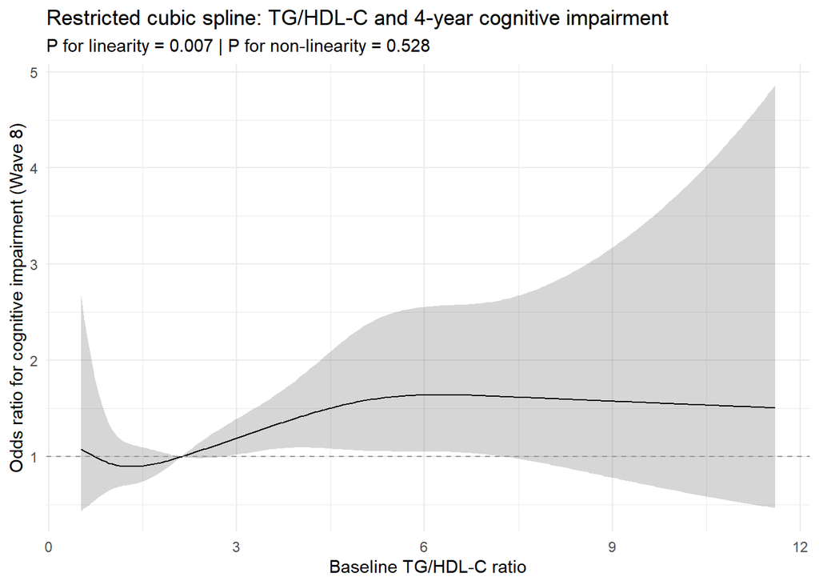

```r
dd <- datadist(dat_6_8)
options(datadist = "dd")

# Define 5 knots at selected percentiles of TG/HDL-C
knots_tg <- quantile(
  dat_6_8$tghdl_cont,
  probs = c(0.01, 0.05, 0.5, 0.95, 0.99),
  na.rm = TRUE
)

fit_lin <- lrm(
  cf8bi ~ tghdl_cont + age + Gender + Education + Marital_Status + Working_Status + Smoking + Alcohol_Consumption + Excercise + bmi + ADL + Depression + Comorbidities + HAQ + GDP,
  data = dat_6_8
)

fit_rcs <- lrm(
  cf8bi ~ rcs(tghdl_cont, knots_tg) +
    age + Gender + Education + Marital_Status + Working_Status + Smoking + Alcohol_Consumption + Excercise + bmi + ADL + Depression + Comorbidities + HAQ + GDP,
  data = dat_6_8
)

anova_lin <- anova(fit_lin)
p_linear  <- anova_lin["tghdl_cont", "P"]

anova_rcs <- anova(fit_rcs)

row_nl <- grep("Nonlinear", rownames(anova_rcs), value = TRUE)
p_nonlinear <- anova_rcs[row_nl, "P"]

format_p <- function(p) {
  if (is.na(p)) return("NA")
  if (p < 0.001) "<0.001" else sprintf("%.3f", p)
}

p_linear_txt    <- paste0("P for linearity = ", format_p(p_linear))
p_nonlinear_txt <- paste0("P for non-linearity = ", format_p(p_nonlinear))

pred_rcs <- Predict(fit_rcs, tghdl_cont, ref.zero = TRUE, fun = exp)

rcs_plot <- as_tibble(pred_rcs) %>%
  ggplot(aes(x = tghdl_cont, y = yhat)) +
  geom_ribbon(aes(ymin = lower, ymax = upper), alpha = 0.2) +
  geom_line() +
  geom_hline(yintercept = 1, linetype = "dashed", color = "grey60") +
  labs(
    x = "Baseline TG/HDL-C ratio",
    y = "Odds ratio for cognitive impairment (Wave 8)",
    title = "Restricted cubic spline: TG/HDL-C and 4-year cognitive impairment",
    subtitle = paste(p_linear_txt, "|", p_nonlinear_txt)
  ) +
  theme_minimal()

rcs_plot
```

```r
library(dplyr)
library(purrr)
library(broom)
library(ggplot2)
library(knitr)
library(rlang)
dat_6_8 <- dat %>%
  filter(cf6bi == 0 & !is.na(cf8bi)) %>%
  mutate(
    outcome = cf8bi
  )

dat_6_8 <- dat_6_8 %>%
  mutate(
    age_group = if_else(age < 75, "<75", "≥75"),
    age_group = factor(age_group, levels = c("<75", "≥75")),

    sex     = factor(Gender),
    edu_cat = factor(Education),

    bmi_group = case_when(
      bmi < 25              ~ "<25",
      bmi >= 25 & bmi < 30  ~ "25–29.9",
      bmi >= 30             ~ "≥30",
      TRUE                  ~ NA_character_
    ),
    bmi_group = factor(bmi_group, levels = c("<25", "25–29.9", "≥30"))
  )

format_or_ci <- function(or, lwr, upr, p, digits = 2) {
  stars <- if (p < 0.001) {
    "***"
  } else if (p < 0.01) {
    "**"
  } else if (p < 0.05) {
    "*"
  } else {
    ""
  }
  sprintf("%.*f (%.*f, %.*f)%s",
          digits, or, digits, lwr, digits, upr, stars)
}

format_p <- function(p) {
  if (is.na(p)) return(NA_character_)
  if (p < 0.001) "<0.001" else sprintf("%.3f", p)
}

base_adjust_vars <- c(
"age", "Gender", "Education", "Marital_Status", "Working_Status", "Smoking", "Alcohol_Consumption", "Excercise", "bmi", "ADL", "Depression", "Comorbidities", "HAQ", "GDP"
)

run_subgroup_with_interaction <- function(data,
                                          subgroup_var,
                                          subgroup_label,
                                          adjust_vars) {
  sg_sym <- sym(subgroup_var)

  data <- data %>%
    filter(!is.na(!!sg_sym)) %>%
    mutate(!!subgroup_var := factor(!!sg_sym))

  levels_vec <- levels(data[[subgroup_var]])

  f_no_int <- as.formula(
    paste(
      "outcome ~ tghdl_cont",
      if (length(adjust_vars) > 0)
        paste("+", paste(adjust_vars, collapse = " + "))
      else "",
      sep = " "
    )
  )

  f_int <- as.formula(
    paste(
      "outcome ~ tghdl_cont *", subgroup_var,
      if (length(adjust_vars) > 0)
        paste("+", paste(adjust_vars, collapse = " + "))
      else "",
      sep = " "
    )
  )

  fit_no_int <- glm(f_no_int, data = data, family = binomial())
  fit_int    <- glm(f_int,    data = data, family = binomial())

  lrt <- anova(fit_no_int, fit_int, test = "LRT")
  p_int <- lrt$`Pr(>Chi)`[2]
  p_int_str <- format_p(p_int)

  map_dfr(
    levels_vec,
    function(lv) {
      df_sub <- data %>%
        filter(!!sg_sym == lv) %>%
        drop_na(tghdl_cont, outcome)

      n_total  <- nrow(df_sub)
      n_events <- sum(df_sub$outcome == 1, na.rm = TRUE)

      if (n_total < 50 || n_events < 5) {
        return(
          tibble(
            Subgroup          = subgroup_label,
            Level             = as.character(lv),
            N                 = n_total,
            Events            = n_events,
            OR_per_unit       = NA_real_,
            CI_lower          = NA_real_,
            CI_upper          = NA_real_,
            p_value           = NA_real_,
            OR_CI_formatted   = "Insufficient data",
            `P for interaction` = ifelse(lv == levels_vec[1], p_int_str, "")
          )
        )
      }

      f_strat <- as.formula(
        paste(
          "outcome ~ tghdl_cont",
          if (length(adjust_vars) > 0)
            paste("+", paste(adjust_vars, collapse = " + "))
          else "",
          sep = " "
        )
      )

      fit_strat <- glm(f_strat, data = df_sub, family = binomial())

      res <- tidy(
        fit_strat,
        exponentiate = TRUE,
        conf.int     = TRUE
      ) %>%
        filter(term == "tghdl_cont")

      or_val  <- res$estimate
      lwr_val <- res$conf.low
      upr_val <- res$conf.high
      p_val   <- res$p.value

      tibble(
        Subgroup          = subgroup_label,
        Level             = as.character(lv),
        N                 = n_total,
        Events            = n_events,
        OR_per_unit       = or_val,
        CI_lower          = lwr_val,
        CI_upper          = upr_val,
        p_value           = p_val,
        OR_CI_formatted   = format_or_ci(or_val, lwr_val, upr_val, p_val),
        `P for interaction` = ifelse(lv == levels_vec[1], p_int_str, "")
      )
    }
  )
}


# Age (age_group), adjust for all except age
sub_age <- run_subgroup_with_interaction(
  data         = dat_6_8,
  subgroup_var = "age_group",
  subgroup_label = "Age",
  adjust_vars  = setdiff(base_adjust_vars, "age")
)
```

[output not shown]

```r
# Sex, adjust for all except sex
sub_sex <- run_subgroup_with_interaction(
  data         = dat_6_8,
  subgroup_var = "Gender",
  subgroup_label = "Gender",
  adjust_vars  = setdiff(base_adjust_vars, "Gender")
)

# BMI group, adjust for all except BMI
sub_bmi <- run_subgroup_with_interaction(
  data         = dat_6_8,
  subgroup_var = "bmi_group",
  subgroup_label = "BMI",
  adjust_vars  = setdiff(base_adjust_vars, "bmi")
)

# Education, adjust for all except edu_cat
sub_edu <- run_subgroup_with_interaction(
  data         = dat_6_8,
  subgroup_var = "Education",
  subgroup_label = "Education",
  adjust_vars  = setdiff(base_adjust_vars, "Education")
)
```

[output not shown]

[output not shown]

[output cut: 21 more lines]

[output not shown]

```r
subgroup_results <- bind_rows(
  sub_age,
  sub_sex,
  sub_bmi,
  sub_edu
)


kable(
  subgroup_results %>%
    select(Subgroup, Level, N, Events, OR_CI_formatted, `P for interaction`),
  caption = "Subgroup analysis: OR (95% CI) per unit increase in TG/HDL-C for 4-year incident cognitive impairment (Wave 6 to Wave 8)",
  align = "llrrcc"
)
```

Subgroup analysis: OR (95% CI) per unit increase in TG/HDL-C for 4-year incident cognitive impairment (Wave 6 to Wave 8)

| Subgroup | Level | N | Events | OR_CI_formatted | P for interaction |
| --- | --- | --- | --- | --- | --- |
| Age | <75 | 3957 | 200 | 1.11 (1.02, 1.19)* | 0.650 |
| Age | ≥75 | 1512 | 100 | 1.08 (0.92, 1.24) |  |
| Gender | Female | 3197 | 167 | 1.12 (1.02, 1.22)** | 0.006 |
| Gender | Male | 2272 | 133 | 1.06 (0.94, 1.19) |  |
| BMI | <25 | 1944 | 98 | 1.17 (1.04, 1.32)** | 0.266 |
| BMI | 25–29.9 | 2302 | 125 | 1.05 (0.92, 1.16) |  |
| BMI | ≥30 | 1223 | 77 | 1.08 (0.93, 1.25) |  |
| Education | Elementary or below | 719 | 96 | 1.03 (0.86, 1.21) | <0.001 |
| Education | Middle/High school | 2726 | 150 | 1.15 (1.05, 1.25)** |  |
| Education | Higher education | 2024 | 54 | 0.96 (0.74, 1.15) |  |

```
`height` was translated to `width`.
```

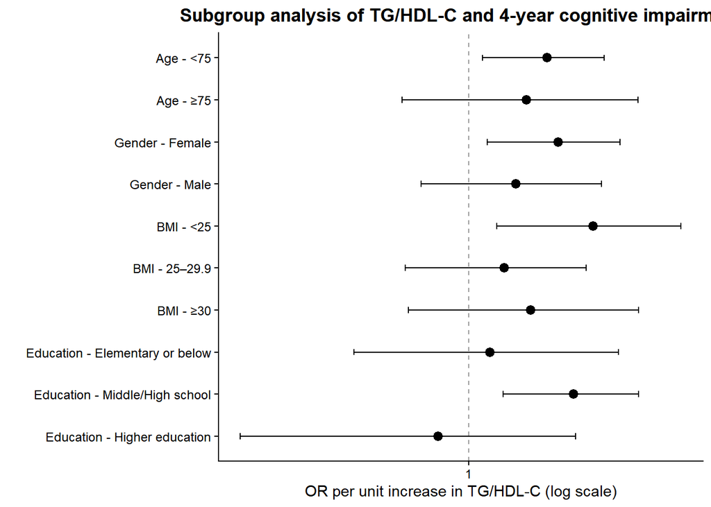

```r
subgroup_results_plot <- subgroup_results %>%
  filter(is.finite(OR_per_unit)) %>%
  mutate(
    label = paste(Subgroup, "-", Level),
    label = factor(label, levels = rev(unique(label)))
  )

ggplot(subgroup_results_plot,
       aes(x = OR_per_unit, y = label)) +
  geom_vline(xintercept = 1, linetype = "dashed", color = "grey60") +
  geom_point(size = 2.8) +
  geom_errorbarh(aes(xmin = CI_lower, xmax = CI_upper), height = 0.15) +
  scale_x_log10(
    breaks = c(0.5, 1, 2, 4),
    labels = c("0.5", "1", "2", "4")
  ) +
  labs(
    x = "OR per unit increase in TG/HDL-C (log scale)",
    y = "",
    title = "Subgroup analysis of TG/HDL-C and 4-year cognitive impairment"
  ) +
  theme_classic(base_size = 11) +
  theme(
    plot.title   = element_text(hjust = 0.5, face = "bold"),
    axis.text.y  = element_text(size = 9),
    axis.text.x  = element_text(size = 9),
    panel.grid   = element_blank()
  )
```

## 1.4 Results

At baseline (Wave 6), participants had a mean age of approximately 71 years, and the average TG/HDL-C ratio was moderately right-skewed. Cognitive performance differed across TG/HDL-C quartiles, with generally lower cognitive scores in participants in the highest quartile. Detailed descriptive statistics for all cognitive domains across TG/HDL-C quartiles are shown in Table 2.

These associations remained robust after adjusting for potential confounders including age, sex, socioeconomic status, lifestyle factors, depressive symptoms, comorbid chronic disease burden, disability, and health-related variables.

Subgroup analyses showed that the positive association between TG/HDL-C and 4-year cognitive impairment was generally consistent across age and BMI categories, with no statistically significant interaction detected (all p-interaction >0.26). Among participants younger than 75 years, higher TG/HDL-C was associated with increased risk (OR = 1.11, 95% CI: 1.02–1.19), similar in magnitude to adults aged ≥75 years (OR = 1.08, 95% CI: 0.92–1.24). Patterns were also stable across BMI strata, with ORs ranging from 1.05 to 1.17. In contrast, heterogeneity was observed by sex (p-interaction = 0.006) and education level (p-interaction < 0.001). Women demonstrated a stronger association (OR = 1.12, 95% CI: 1.02–1.22) than men (OR = 1.06, 95% CI: 0.94–1.19). Similarly, participants with middle/high school education showed clearer risk elevation (OR = 1.15, 95% CI: 1.05–1.25), whereas those with higher education did not exhibit a significant association (OR = 0.96, 95% CI: 0.74–1.15). Overall, while TG/HDL-C was positively associated with cognitive impairment in several subgroups, the strength of the association varied notably by sex and educational attainment.